# Week 6, Lecture 11 Advanced statistical methods, part II: Structural equation modeling, social network analysis, and geospatial analyses

Richard E.W. Berl

Spring 2019

## Structural equation modeling

One common use of structural equation modeling (SEM) is confirmatory factor analysis (CFA), which allows us to test how well our data fit in the factors that we think they should in our model. Naturally, a good way to find this model in the first place is through EFA, and doing this process all together in an SEM framework is sometimes called E/CFA. There are other types of SEM analyses, including path analysis. Here we’ll focus on EFA and CFA, but the methods and tools are similar across other types of SEM.

We’ll use the items from the “Nerdy Personality Attributes Scale” to build and evaluate our model. Download the data here: https://openpsychometrics.org/_rawdata/

On the right side, click “NPAS-data-16December2018.zip” to download the ZIP file with the data and codebook. More info is available on the page for the scale itself (and the link below on its development): https://openpsychometrics.org/tests/NPAS/

After extracting the CSV file, place it in your `/data` folder and rename it to `npas.txt` (since it’s actually tab delimited, not comma delimited).

Then load it in, using the `readr` package due to a few messed up rows:

```r
library(readr)
```

```r
nerd = as.data.frame(read_tsv("./data/npas.txt"))
head(nerd)
```

```
##   Q1 Q2 Q3 Q4 Q5 Q6 Q7 Q8 Q9 Q10 Q11 Q12 Q13 Q14 Q15 Q16 Q17 Q18 Q19 Q20
## 1  3  5  3  3  5  5  5  3  5   5   4   5   5   5   3   5   4   5   5   5
## 2  4  4  4  3  5  2  5  1  4   4   1   5   4   4   1   3   3   3   1   3
## 3  5  5  5  5  5  5  5  5  5   5   5   4   5   5   4   5   5   4   5   5
## 4  5  5  5  5  5  5  5  3  5   5   5   5   4   4   4   2   5   5   5   5
## 5  4  4  4  4  4  4  4  4  4   5   4   4   5   5   1   1   5   5   3   5
## 6  4  4  4  4  4  4  5  3  3   4   4   4   3   5   3   4   3   4   5   4
##   Q21 Q22 Q23 Q24 Q25 Q26 country introelapse testelapse surveyelapse
## 1   5   5   5   5   5   5      US          41         93          125
## 2   3   3   4   4   4   5      GB          13        131          161
## 3   5   5   5   5   3   5      PL           2         49           87
## 4   4   1   5   5   5   5      US          26        710          228
## 5   5   4   4   5   4   0      US           6        195          424
## 6   4   2   5   5   3   4      US         410        117          113
##   TIPI1 TIPI2 TIPI3 TIPI4 TIPI5 TIPI6 TIPI7 TIPI8 TIPI9 TIPI10 VCL1 VCL2
```

[output cut: 41 more lines]

```r
str(nerd, give.attr=F)
```

```
## 'data.frame':    19749 obs. of  80 variables:
##  $ Q1           : num  3 4 5 5 4 4 5 5 5 4 ...
##  $ Q2           : num  5 4 5 5 4 4 3 3 5 5 ...
##  $ Q3           : num  3 4 5 5 4 4 4 4 5 5 ...
##  $ Q4           : num  3 3 5 5 4 4 3 5 4 5 ...
##  $ Q5           : num  5 5 5 5 4 4 5 5 2 4 ...
##  $ Q6           : num  5 2 5 5 4 4 4 3 3 3 ...
##  $ Q7           : num  5 5 5 5 4 5 4 3 0 5 ...
##  $ Q8           : num  3 1 5 3 4 3 5 5 5 4 ...
##  $ Q9           : num  5 4 5 5 4 3 5 3 4 4 ...
##  $ Q10          : num  5 4 5 5 5 4 5 5 4 5 ...
##  $ Q11          : num  4 1 5 5 4 4 3 4 4 1 ...
##  $ Q12          : num  5 5 4 5 4 4 3 4 4 4 ...
##  $ Q13          : num  5 4 5 4 5 3 4 3 5 4 ...
##  $ Q14          : num  5 4 5 4 5 5 4 5 3 5 ...
```

[output cut: 66 more lines]

We can see that, along with the “nerdiness” questions, there are a number of other scale items and demographic variables represented. Let’s change each of the Likert variables (and education) to ordered, using `lapply()`.

```r
colnames(nerd)
```

```
##  [1] "Q1"            "Q2"            "Q3"            "Q4"
##  [5] "Q5"            "Q6"            "Q7"            "Q8"
##  [9] "Q9"            "Q10"           "Q11"           "Q12"
## [13] "Q13"           "Q14"           "Q15"           "Q16"
## [17] "Q17"           "Q18"           "Q19"           "Q20"
## [21] "Q21"           "Q22"           "Q23"           "Q24"
## [25] "Q25"           "Q26"           "country"       "introelapse"
## [29] "testelapse"    "surveyelapse"  "TIPI1"         "TIPI2"
## [33] "TIPI3"         "TIPI4"         "TIPI5"         "TIPI6"
## [37] "TIPI7"         "TIPI8"         "TIPI9"         "TIPI10"
## [41] "VCL1"          "VCL2"          "VCL3"          "VCL4"
## [45] "VCL5"          "VCL6"          "VCL7"          "VCL8"
## [49] "VCL9"          "VCL10"         "VCL11"         "VCL12"
## [53] "VCL13"         "VCL14"         "VCL15"         "VCL16"
## [57] "education"     "urban"         "gender"        "engnat"
## [61] "age"           "screenw"       "screenh"       "hand"
## [65] "religion"      "orientation"   "voted"         "married"
## [69] "familysize"    "major"         "race_arab"     "race_asian"
## [73] "race_black"    "race_white"    "race_hispanic" "race_nativeam"
## [77] "race_nativeau" "race_other"    "nerdy"         "ASD"
```

```r
nerd[,c(1:26,31:40,57,79)] = lapply(nerd[,c(1:26,31:40,57,79)], function(x) ordered(x))
```

### Exploratory factor analysis

First we’ll load up the packages we’ll need: `psych` for parallel analysis to determine our number of factors, and `lavaan` and `semTools` for the EFA and CFA.

```r
library(psych)
```

```r
library(lavaan)
install.packages("semTools")
```

```r
library(semTools)
```

One important point in the E/CFA process is that we can’t build our model and evaluate our model using the same data. If we did, we would risk building a model that is only valid for that particular data set. The best way to counteract this would be to collect two separate data sets and use one for EFA an the other for CFA. Since here we only have one data set to work with, we’ll do the next best thing, which is to split it randomly into two sets that we use for the two steps of E/CFA. Following convention in machine learning, in which this kind of splitting is common for training and validating predictive models, we’ll call them the “train” and “test” sets, respectively.

To split the data, we’ll use the `sample()` function to randomly select half of the rows in the data frame (rounded to an even digit). We use those rows are our train set, and the rest of the rows for our test set. Before sampling, we set the seed for the random number generator in R, so that if someone else goes to run our code they will get the same result. I tend to use the current date as my seed, but you could use any number.

```r
set.seed(20190430)
trainSet = sample(nrow(nerd), round(nrow(nerd)/2))
nerdTrain = nerd[trainSet,]
nerdTest = nerd[-trainSet,]
head(nerdTrain)
```

```
##       Q1 Q2 Q3 Q4 Q5 Q6 Q7 Q8 Q9 Q10 Q11 Q12 Q13 Q14 Q15 Q16 Q17 Q18 Q19
## 12801  1  5  2  4  4  4  5  4  4   1   1   5   2   4   1   1   1   5   1
## 178    2  5  2  2  4  3  5  5  2   4   5   5   4   4   3   3   3   2   5
## 15165  4  4  5  5  4  4  5  3  4   3   1   4   2   4   1   1   4   5   2
## 7646   5  4  5  5  5  4  4  4  4   5   1   4   3   3   4   3   4   5   1
## 3162   5  1  5  5  4  4  3  1  5   4   1   3   3   5   1   5   5   1   1
## 10896  4  5  4  2  1  5  4  4  4   4   3   4   4   4   4   2   3   5   3
##       Q20 Q21 Q22 Q23 Q24 Q25 Q26 country introelapse testelapse
## 12801   4   1   1   1   4   1   5      IE        1103         83
## 178     3   4   2   2   3   3   3      CA          12         84
## 15165   4   1   2   1   4   3   5      US          21        131
## 7646    4   5   3   4   5   2   4    NONE          64        173
## 3162    4   3   5   5   5   1   2      US           5        107
## 10896   3   2   3   5   4   4   4      US          11        100
##       surveyelapse TIPI1 TIPI2 TIPI3 TIPI4 TIPI5 TIPI6 TIPI7 TIPI8 TIPI9
```

[output cut: 41 more lines]

```r
head(nerdTest)
```

```
##   Q1 Q2 Q3 Q4 Q5 Q6 Q7 Q8 Q9 Q10 Q11 Q12 Q13 Q14 Q15 Q16 Q17 Q18 Q19 Q20
## 1  3  5  3  3  5  5  5  3  5   5   4   5   5   5   3   5   4   5   5   5
## 2  4  4  4  3  5  2  5  1  4   4   1   5   4   4   1   3   3   3   1   3
## 3  5  5  5  5  5  5  5  5  5   5   5   4   5   5   4   5   5   4   5   5
## 4  5  5  5  5  5  5  5  3  5   5   5   5   4   4   4   2   5   5   5   5
## 6  4  4  4  4  4  4  5  3  3   4   4   4   3   5   3   4   3   4   5   4
## 7  5  3  4  3  5  4  4  5  5   5   3   3   4   4   1   1   3   1   3   1
##   Q21 Q22 Q23 Q24 Q25 Q26 country introelapse testelapse surveyelapse
## 1   5   5   5   5   5   5      US          41         93          125
## 2   3   3   4   4   4   5      GB          13        131          161
## 3   5   5   5   5   3   5      PL           2         49           87
## 4   4   1   5   5   5   5      US          26        710          228
## 6   4   2   5   5   3   4      US         410        117          113
## 7   5   1   4   5   3   5      US           7        107          145
##   TIPI1 TIPI2 TIPI3 TIPI4 TIPI5 TIPI6 TIPI7 TIPI8 TIPI9 TIPI10 VCL1 VCL2
```

[output cut: 41 more lines]

Then, to proceed with our EFA, we build a correlation matrix of the “nerdiness” scale items.

```r
nerdCor = lavCor(nerdTrain[,c(1:26)])
```

```r
dim(nerdCor)
```

```
## [1] 26 26
```

```r
nerdCor[1:10,1:10]
```

```
##            Q1        Q2        Q3        Q4        Q5        Q6        Q7
## Q1  1.0000000 0.2136586 0.4296777 0.6261649 0.2710970 0.2127082 0.1573807
## Q2  0.2136586 1.0000000 0.1826554 0.2220183 0.2216742 0.2021222 0.3988995
## Q3  0.4296777 0.1826554 1.0000000 0.3755428 0.1768708 0.2290472 0.1014630
## Q4  0.6261649 0.2220183 0.3755428 1.0000000 0.3002433 0.2415370 0.1656149
## Q5  0.2710970 0.2216742 0.1768708 0.3002433 1.0000000 0.3501039 0.3710673
## Q6  0.2127082 0.2021222 0.2290472 0.2415370 0.3501039 1.0000000 0.2492080
## Q7  0.1573807 0.3988995 0.1014630 0.1656149 0.3710673 0.2492080 1.0000000
## Q8  0.3799838 0.3032137 0.4246551 0.3222260 0.1638154 0.2601828 0.0573631
## Q9  0.2235768 0.2555981 0.1163953 0.2475506 0.4768827 0.4460943 0.3729157
## Q10 0.2593911 0.1776734 0.3222602 0.2636585 0.3251740 0.3110858 0.2065492
##            Q8        Q9       Q10
## Q1  0.3799838 0.2235768 0.2593911
## Q2  0.3032137 0.2555981 0.1776734
## Q3  0.4246551 0.1163953 0.3222602
## Q4  0.3222260 0.2475506 0.2636585
## Q5  0.1638154 0.4768827 0.3251740
## Q6  0.2601828 0.4460943 0.3110858
## Q7  0.0573631 0.3729157 0.2065492
## Q8  1.0000000 0.1785132 0.2282437
## Q9  0.1785132 1.0000000 0.2980757
## Q10 0.2282437 0.2980757 1.0000000
```

To stick with a consistent set of tools, we’ll use `efaUnrotate()` in the `semTools` package to run our EFA this time.

```r
?semTools::efaUnrotate
```

Before we do, we need to determine the appropriate number of factors. Instead of maximum likelihood estimation (`ml`), in this case we’ll use weighted least squares methods (`wls`) because they tend to be more appropriate for ordinal data.

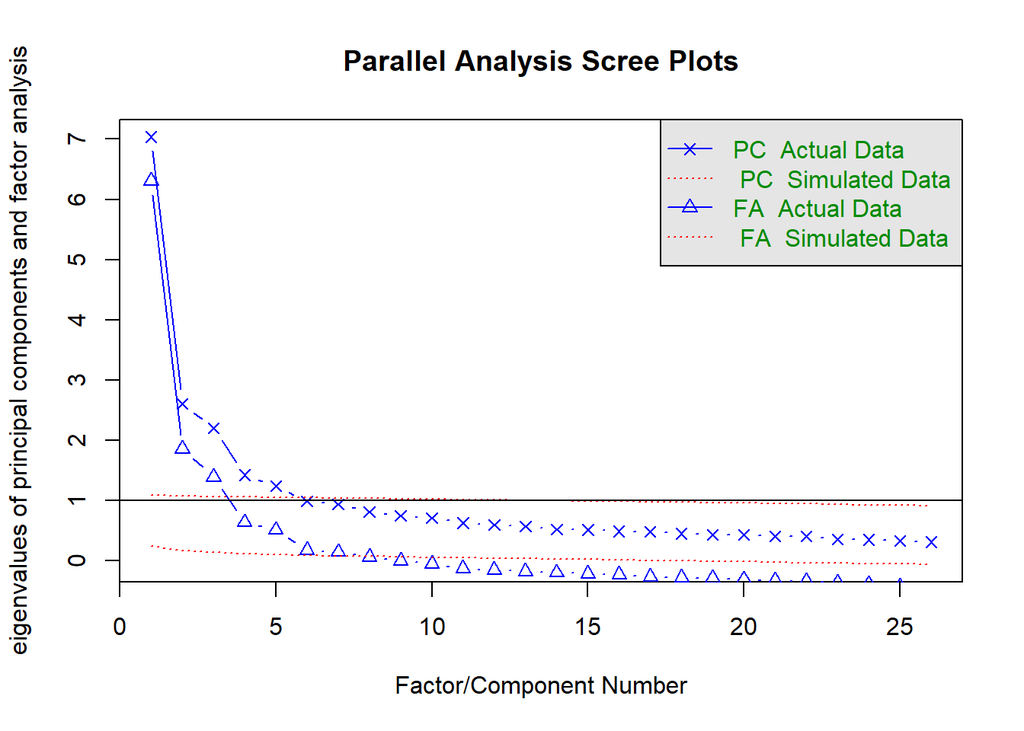

```
## Parallel analysis suggests that the number of factors =  7  and the number of components =  5
```

```r
fa.parallel(nerdCor, fm="wls", n.obs=nrow(nerdTrain))
```

Looks like 7. Let’s give it a try. `efaUnrotate()` takes raw data, but knows what to do with our ordinal variables, so it’s okay to use them.

Here we use `WLSMV` as our estimator, which is a statistically robust variant (meaning: good for both normal and non-normal data) of WLS available in `lavaan` and `semTools`. A list of options are available on the `lavaan` “Estimators” webpage: http://lavaan.ugent.be/tutorial/est.html

```r
# Note: long run time
nerdEFA = efaUnrotate(nerdTrain[,c(1:26)],
                      nf=7, estimator="WLSMV")
```

Then, just like our previous work with EFA, we rotate the result. Here I use `oblimin` rotation again, because we expect our different factors may be correlated (since they all measure “nerdiness”).

```r
nerdEFA.O = oblqRotate(nerdEFA, method="oblimin")
nerdEFA.O
```

```
## Standardized Rotated Factor Loadings
##     factor1 factor2 factor3 factor4 factor5 factor6 factor7
## Q17 -0.761*
## Q13 -0.629*          0.104*                 -0.147* -0.236*
## Q16 -0.597*                 -0.140*
## Q3  -0.499* -0.111* -0.337*
## Q8  -0.436*         -0.171*                 -0.333*
## Q10 -0.292*  0.276*
## Q22 -0.285*  0.189*          0.113*         -0.271* -0.189*
## Q5           0.682*                  0.104*
## Q24          0.579* -0.121*          0.116*
## Q26          0.507*                  0.160*         -0.205*
## Q9           0.495*                  0.107* -0.123* -0.222*
## Q1                  -0.778*
## Q4                  -0.756*
## Q19                         -0.866*
## Q11                         -0.750*         -0.115*
## Q7                                   0.751*  0.115* -0.122*
## Q12                                  0.728*
## Q2                          -0.179*  0.534* -0.358*
## Q25          0.248*         -0.145*  0.502*
## Q15         -0.168*         -0.134*  0.206* -0.536*
## Q23          0.246*          0.110*         -0.470* -0.276*
## Q21          0.250* -0.152*         -0.217* -0.400*
## Q6           0.141*                         -0.144* -0.513*
## Q18  0.195*         -0.111*                         -0.491*
## Q20 -0.359*                          0.178*  0.130* -0.436*
## Q14 -0.201*                          0.139*  0.109* -0.320*
##
## Factor Correlation
##            factor1     factor2    factor3     factor4     factor5
## factor1  1.0000000 -0.19992781  0.4353482  0.20338370 -0.12370052
## factor2 -0.1999278  1.00000000 -0.2843631 -0.02436977  0.42249015
## factor3  0.4353482 -0.28436309  1.0000000  0.30746979 -0.21769809
## factor4  0.2033837 -0.02436977  0.3074698  1.00000000 -0.29241720
## factor5 -0.1237005  0.42249015 -0.2176981 -0.29241720  1.00000000
## factor6  0.2430809 -0.14202300  0.2115626  0.13406027 -0.07220745
## factor7  0.3011301 -0.51064846  0.1433126 -0.12776643 -0.23331675
##             factor6    factor7
## factor1  0.24308089  0.3011301
## factor2 -0.14202300 -0.5106485
## factor3  0.21156265  0.1433126
## factor4  0.13406027 -0.1277664
## factor5 -0.07220745 -0.2333167
## factor6  1.00000000  0.2314242
## factor7  0.23142418  1.0000000
##
## Method of rotation:  Oblimin Quartimin
## [1] "The standard errors are close but do not match with other packages. Be mindful when using it."
```

And we get our 7 factors with the loadings for each item. It conveniently organizes them from highest-to-lowest loading (positive or negative) for the first factor, then for the next factor, and so on. It’s okay to see high negative loadings for some items on some factors–it means that those items are strongly opposed to the positive items in that factor.

However, this immediately alerts us to a problem with this model, in that we don’t have *any* high positive loadings on the first factor. The highest is Q18 (“I love to read challenging material”), but it’s below 0.2, which means it really doesn’t fit there either.

The problem here is that we have too many factors, even though parallel analysis said this was the best fit. This is called “overdimensionalization” and sometimes happens with ordinal data like Likert surveys. Here is a reference to read more about it:

- van der Eijk, C., & Rose, J. (2015). Risky business: Factor analysis of survey data – Assessing the probability of incorrect dimensionalisation. *PLOS ONE, 10*(3), e0118900. doi: 10.1371/journal.pone.0118900

The solution is just to drop a factor. So we do:

```r
# Note: long run time
nerdEFA = efaUnrotate(nerdTrain[,c(1:26)],
                      nf=6, estimator="WLSMV")
```

```r
nerdEFA.O = oblqRotate(nerdEFA, method="oblimin")
nerdEFA.O
```

```
## Standardized Rotated Factor Loadings
##     factor1 factor2 factor3 factor4 factor5 factor6
## Q23  0.699*         -0.243*
## Q9   0.603*          0.108*                  0.183*
## Q6   0.571*  0.156*
## Q26  0.513*          0.245*  0.120*          0.251*
## Q21  0.464*         -0.212*  0.187* -0.102* -0.192*
## Q24  0.451*          0.152*  0.230*          0.222*
## Q22  0.442*  0.277*
## Q5   0.391*          0.262*  0.201*          0.235*
## Q18  0.347*                                  0.154*
## Q17          0.725*          0.140*
## Q13  0.323*  0.666*         -0.130*
## Q16 -0.157*  0.592*          0.116* -0.125*
## Q3  -0.119*  0.545*          0.308*
## Q20  0.241*  0.458*  0.130*                  0.196*
## Q8           0.444* -0.330*  0.183*
## Q14  0.235*  0.281*  0.157*                  0.185*
## Q10  0.230*  0.266*  0.165*  0.163*
## Q15                 -0.550*         -0.138*  0.146*
## Q1                           0.767*
## Q4                           0.746*
## Q19                                 -0.870*
## Q11                                 -0.765*
## Q7                                           0.811*
## Q12                 -0.128*                  0.784*
## Q25                                 -0.200*  0.555*
## Q2                  -0.416*         -0.186*  0.502*
##
## Factor Correlation
##             factor1    factor2     factor3     factor4     factor5
## factor1  1.00000000  0.3301510 -0.03697804  0.27620315  0.01337266
## factor2  0.33015100  1.0000000 -0.16333641  0.41772927 -0.19033071
## factor3 -0.03697804 -0.1633364  1.00000000 -0.08160535  0.17238051
## factor4  0.27620315  0.4177293 -0.08160535  1.00000000 -0.31085697
## factor5  0.01337266 -0.1903307  0.17238051 -0.31085697  1.00000000
## factor6  0.38927694  0.1571819  0.10638474  0.26261581 -0.27637983
##            factor6
## factor1  0.3892769
## factor2  0.1571819
## factor3  0.1063847
## factor4  0.2626158
## factor5 -0.2763798
## factor6  1.0000000
##
## Method of rotation:  Oblimin Quartimin
## [1] "The standard errors are close but do not match with other packages. Be mindful when using it."
```

Looks better, but we have only negative loadings on factor 5 now (and spoiler: 5 factors doesn’t work well either). At this point the better approach would probably be for us to drop some of the more problematic items and re-run analyses from the start. For this lecture, I’m just going to cut it down to 4 factors so we have something to use for our CFA.

```r
# Note: long run time
nerdEFA = efaUnrotate(nerdTrain[,c(1:26)],
                      nf=4, estimator="WLSMV")
nerdEFA.O = oblqRotate(nerdEFA, method="oblimin")
nerdEFA.O
```

```
## Standardized Rotated Factor Loadings
##     factor1 factor2 factor3 factor4
## Q7   0.760*                  0.178*
## Q12  0.649*                  0.254*
## Q26  0.625*  0.151* -0.123* -0.186*
## Q5   0.568*         -0.244* -0.103*
## Q25  0.560* -0.107*          0.259*
## Q24  0.557*  0.122* -0.181*
## Q9   0.544*  0.304*         -0.114*
## Q18  0.356*  0.159*
## Q14  0.308*  0.213* -0.175*
## Q23  0.170*  0.686*  0.115*
## Q13          0.646* -0.177*
## Q22  0.105*  0.548*
## Q8  -0.163*  0.511* -0.256*  0.252*
## Q6   0.306*  0.494*         -0.153*
## Q21          0.411*
## Q20  0.244*  0.362* -0.162*
## Q1   0.101*         -0.753*
## Q4   0.160*         -0.703*
## Q3  -0.139*  0.236* -0.536*  0.105*
## Q17 -0.102*  0.360* -0.482*  0.162*
## Q16 -0.168*  0.253* -0.405*  0.230*
## Q10  0.219*  0.193* -0.304*
## Q19         -0.135* -0.102*  0.752*
## Q11                          0.716*
## Q2   0.319*  0.234*  0.107*  0.494*
## Q15          0.362*          0.429*
##
## Factor Correlation
##            factor1     factor2    factor3     factor4
## factor1  1.0000000  0.29674975 -0.1988301  0.11859358
## factor2  0.2967497  1.00000000 -0.4175340  0.05306424
## factor3 -0.1988301 -0.41753403  1.0000000 -0.26056564
## factor4  0.1185936  0.05306424 -0.2605656  1.00000000
##
## Method of rotation:  Oblimin Quartimin
## [1] "The standard errors are close but do not match with other packages. Be mindful when using it."
```

If we want more details, like standard error values and confidence intervals, we could run:

```r
summary(nerdEFA.O)
```

We can use `fitMeasures()` to look at a number of different criteria used to assess the fit of the EFA. We can also look at the r squared values (“communalities”) for each item to see how well it fits. We’ll come back to these for the CFA.

```r
fitMeasures(nerdEFA, c("chisq","df","pvalue","cfi","tli","rmsea","srmr"))
```

```
##    chisq       df   pvalue      cfi      tli    rmsea     srmr
## 6155.099  227.000    0.000    0.978    0.968    0.051    0.042
```

```r
inspect(nerdEFA, "rsquare")
```

```
##    Q1    Q2    Q3    Q4    Q5    Q6    Q7    Q8    Q9   Q10   Q11   Q12
## 0.569 0.444 0.458 0.518 0.462 0.449 0.599 0.498 0.494 0.267 0.569 0.520
##   Q13   Q14   Q15   Q16   Q17   Q18   Q19   Q20   Q21   Q22   Q23   Q24
## 0.535 0.262 0.291 0.388 0.546 0.182 0.618 0.327 0.206 0.340 0.509 0.445
##   Q25   Q26
## 0.396 0.523
```

Here are how each of our factors breaks down. Sometimes it’s helpful to assign labels to your constructs to help make sense of them (though the labels themselves are arbitrary).

Factor 1 (“Geek”):

```
Q7  I watch science related shows.
Q12 I spend more time at the library than any other public place.
Q26 I can be socially awkward at times.
Q5  I collect books.
Q25 I care about super heroes.
Q9  I like science fiction.
Q24 I am a strange person.
Q18 I love to read challenging material.
Q14 I like to read technology news reports.
```

Factor 2 (“Reader”):

[output not shown]

Factor 3 (“Know-it-all”):

```
Q1  I am interested in science.
Q4  My appearance is not as important as my intelligence.
Q3  I like to play RPGs. (Ex. D&D)
```

Factor 4 (“Gamer”):

```
Q19 I have played a lot of video games.
Q11 I am more comfortable with my hobbies than I am with other people.
Q2  I was in advanced classes.
Q15 I have started writing a novel.
```

Then, for our subsequent analysis, we’ll need to define this model in a way that `lavaan` can understand. There are details on the syntax in their tutorial [here (part 1)](http://lavaan.ugent.be/tutorial/syntax1.html) and [here (part 2)](http://lavaan.ugent.be/tutorial/syntax2.html).

```r
nerdModel =  "nerd =~ geek + reader + knowitall + gamer
              geek =~ Q7 + Q12 + Q26 +Q5 + Q25 + Q9 + Q24 + Q18 + Q14
              reader =~ Q13 + Q23 + Q22 + Q8 + Q17 + Q6 + Q20 + Q21 + Q16 + Q10
              knowitall =~ Q1 + Q4 + Q3
              gamer =~ Q19 + Q11 + Q2 + Q15"
```

Essentially we’re telling it that `geek`, `reader`, `knowitall` and `gamer` are our 4 factors, and that they all contribute to a second-order factor called `nerd`.